# Quality control of high-throughput sequencing data

Author

Prof. Francesca Finotello

# Introduction

High-throughput sequencing (HTS) has revolutionized genomics by enabling the rapid and cost-effective profiling of DNA and RNA at an unprecedented scale. However, HTS data may contain technical artifacts that can compromise mapping accuracy, bias quantification, and lead to false positives. Quality control (QC) is therefore essential to identify such issues early, prior to alignment or quantification.

[FastQC](https://www.bioinformatics.babraham.ac.uk/projects/fastqc/) is a widely used QC tool for HTS data, particularly for raw FASTQ files generated by platforms such as Illumina. FastQC provides a modular set of analyses that enable a rapid overview of the input data, summarized in an easy-to-interpret HTML QC report containing a range of diagnostic statistics and visualizations.

Each QC module assigns a *pass/warn/fail* flag to indicate the quality of the data for that specific metric. These flags provide guidance but are not absolute indicators of overall data quality. Their interpretation depends on the type of experiment and the library preparation method: some experiments naturally produce libraries with biases or characteristics that trigger *warn* or *fail* flags in certain modules, yet the resulting data may still be suitable for downstream analysis. Understanding the context behind these flags is therefore essential for making informed decisions about data usability.

FastQC can be run from the command line with a simple call such as:

`fastqc sample_R1.fastq.gz sample_R2.fastq.gz`

This command generates an HTML report and a ZIP archive for each input file in the same directory. The HTML report can be opened in a web browser to visually inspect the quality control results.

In this exercise, we will not run FastQC ourselves but will instead directly examine its output reports to learn how to interpret them.

## Interpreting FastQC results

The following sections provide a summary of the main FastQC modules and guidance on how to interpret their results.

**Basic statistics**: composition statistics for the file analysed, encompassing:

- Filename
- File type
- Encoding: ASCII encoding of quality values
- Total Sequences: total number of sequences (i.e., reads) processed
- Filtered Sequences: number of sequences flagged to be removed from the analysis (not included in “total sequences”)
- Sequence Length: length of the shortest and longest sequence in the set
- %GC: Overall GC-content (i.e., percentage of G and C bases) considering all bases in all sequences

**Per base sequence quality**: overview of the range of quality values across all bases at each position in the FASTQ file, represented as a BoxWhisker plot for each base:

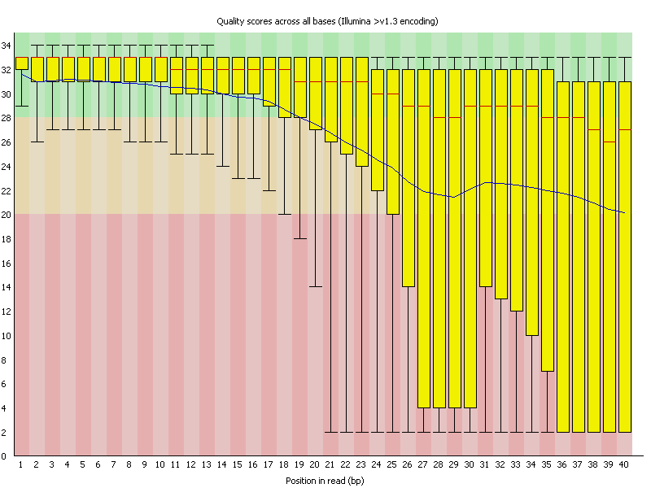

In this plot:

- The y-axis on the graph shows the quality scores; the higher the score, the better the base call
- The central red line represents the median
- The upper and lower whiskers represent the 10% and 90% *percentiles*, i.e., the values below which 10% and 90% of the data fall.
- The yellow box represents the *interquartile* range, i.e., the range of values between the 25th percentile (lower quartile) and the 75th percentile (upper quartile).
- The blue line represents the mean
- The background of the graph divides the y axis into very good quality calls (green), calls of reasonable quality (orange), and calls of poor quality (red). On most sequencing platforms, base-call quality degrades as the run progresses, so it is common to observe base calls falling into the orange region toward the end of a read.

The possible flags from this module are:

- **Warning**: if the lower quartile for any base is less than 10 or if the median for any base is less than 25.
- **Failure**: if the lower quartile for any base is less than 5 or if the median for any base is less than 20.

If the quality of a library drops to a low level towards the end of the reads, the most common remedy is to perform quality *trimming*, in which reads are truncated based on to remove low-quality “tails”.

**Per tile sequence quality**: deviation from the average quality for each tile. This graph is shown only for Illumina libraries that retain their original sequence identifiers, which encode the *flowcell tile* for each read, i.e. the rectangular region on the flowcell where clusters of DNA fragments are imaged and sequenced. It displays quality scores per tile across all bases, allowing detection of quality loss confined to specific regions of the flowcell.

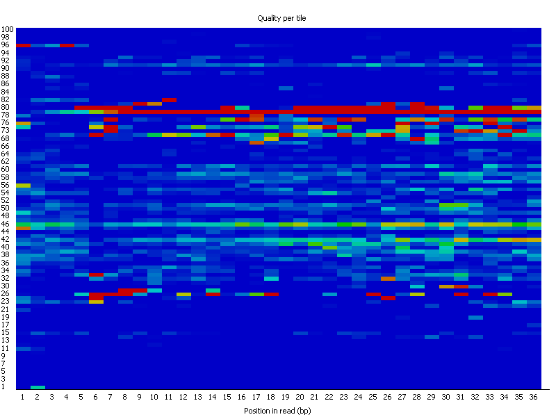

Colours follow a cold-to-hot scale: cold colours indicate quality at or above the run average for that base, while hot colours indicate lower quality compared with other tiles. A good plot should be uniformly blue.

Flags:

- **Warning**: if any tile shows a mean Phred score more than 2 less than the mean for that base across all tiles.
- **Failure**: if any tile shows a mean Phred score more than 5 less than the mean for that base across all tiles.

Warnings or errors in this plot may result from transient issues (e.g., bubbles passing through the flowcell) or more persistent problems (e.g., debris in a flowcell lane). Minor effects affecting a few tiles for only one or two cycles can be usually ignored, whereas larger deviations or issues persisting across multiple cycles should be investigated.

**Per sequence quality scores**: distribution of average quality scores across all reads, with the average quality per read on the x-axis (the higher, the better) and the number of reads with that quality on the y-axis. It allows to see if a subset of the sequences have universally low quality values.

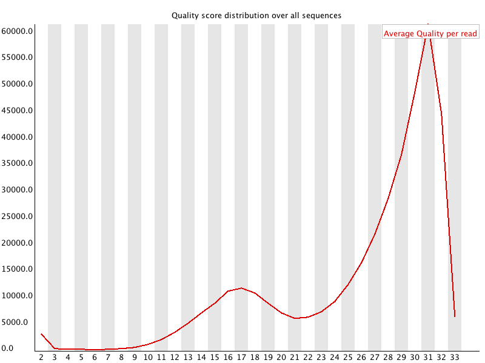

It is often the case that a subset of sequences have universally low quality, often because they are poorly imaged, but these should represent only a small percentage of the total sequences. If a large proportion of the sequences in a run have overall low quality then this could indicate some kind of systematic problem, possibly with just part of the run (e.g., one end of a flowcell).

Flags:

- **Warning**: if the most frequently observed mean quality is below 27 (i.e., 0.2% error rate).
- **Failure**: if the most frequently observed mean quality is below 20 - this equates (i.e., 1% error rate).

Warnings usually indicate a general loss of quality within a run. For long runs, this may be alleviated through quality trimming.

**Per base sequence content**: proportion of each DNA base (A, C, G, T) at every position along the read (x-axis), with separate colors/curves for each base (y-axis):

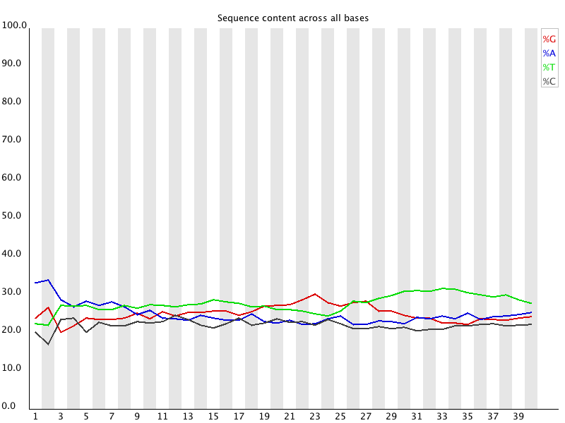

In a random library, little to no difference is expected between the different bases across a read, so the lines in this plot should run roughly parallel. The relative proportions of each base should reflect the overall composition of the genome and, more generally, should not be strongly imbalanced relative to one another.

It is worth noting that some library types will always produce biased sequence composition, typically at the start of the read. Libraries generated using random hexamer priming (including nearly all RNA-seq libraries) show an intrinsic bias in the positions where reads begin. This bias does not reflect a single overrepresented sequence, but rather an enrichment of various short sequences (k-mers) at the 5’ end of reads, which can trigger a warning or failure in this module.

Flags:

- **Warning**: if the difference between A and T, or G and C is greater than 10% in any position.
- **Failure**: if the difference between A and T, or G and C is greater than 20% in any position.

Common reasons for warnings include:

- *Overrepresented sequences*: Evidence of overrepresented sequences, such as adapter dimers or rRNA contamination, can bias the overall sequence composition. When present, these sequences will be highlighted in this module.
- *Biased fragmentation*: Libraries generated using random hexamer priming are expected to show good sequence diversity. However, in practice they often exhibit a selection bias in the first ~12 bp of each read. This bias arises from non-uniform primer selection rather than from specific over-represented sequences. As a result, most RNA-seq libraries fail this module. Importantly, this bias cannot be corrected by data processing and does not appear to adversely affect expression quantification.
- *Biased composition libraries*: Some library types are inherently biased in their sequence composition. A common example is sodium bisulfite–treated libraries aimed at quantifying DNA methylation, in which most cytosines are converted to thymines. This leads to a marked depletion of cytosines and may trigger warnings or failures, despite being entirely expected for this library type.

**Per sequence GC content**: GC content (y-axis) across the whole length of each sequence (y-axis, in read) in the data, compared to a modelled normal distribution of GC content (in blue).

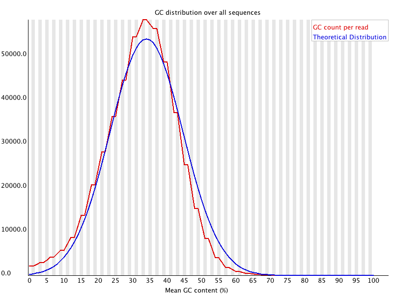

In a typical random library, GC content is expected to follow an approximately normal distribution, with the central peak corresponding to the overall GC content of the underlying genome. Since the true genome GC content is often unknown, FastQC calculates the modal GC content from the observed data and uses it to construct a reference distribution.

An unusually shaped GC content distribution may indicate a contaminated library or a biased subset of sequences. A normal distribution that is shifted from the expected position suggests a systematic bias that is independent of base position. Because FastQC does not know the true GC content of the genome, such a shifted distribution will not necessarily be flagged as an error by this module.

Flags:

- **Warning**: if the sum of the deviations from the normal distribution represents more than 15% of the reads.
- **Failure**: if the sum of the deviations from the normal distribution represents more than 30% of the reads.

Warnings in this module generally indicate potential issues with the library. Sharp peaks on an otherwise smooth GC content distribution are usually caused by a specific *contaminant*, such as adapter dimers, which may also be detected by the over-represented sequences module. Broader peaks may indicate contamination from a different species.

**Per base N content** percentage of N base calls (y-axis) at each read position (x-axis), indicating bases that the sequencer could not confidently determine:

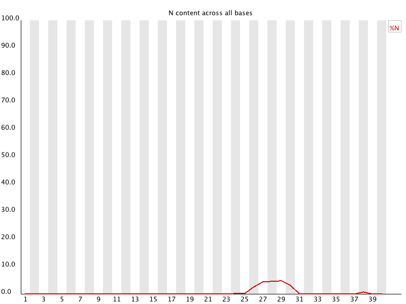

A low proportion of Ns, especially nearer the end of a sequence, can be expected. However, if this proportion rises above a few percent it suggests that the analysis pipeline was unable to interpret the data well enough to make valid base calls.

Flags:

- **Warning**: This module raises a warning if any position shows an N content of >5%.
- **Failure**: This module will raise an error if any position shows an N content of >20%.

The most common reason for a high proportion of Ns is a general loss of sequencing quality. Therefore, the results of this module should be interpreted alongside the other quality metrics.

**Sequence length distribution**: distribution of read lengths in the dataset, with read length (in bases) on the x-axis and the number of reads at each length on the y-axis:

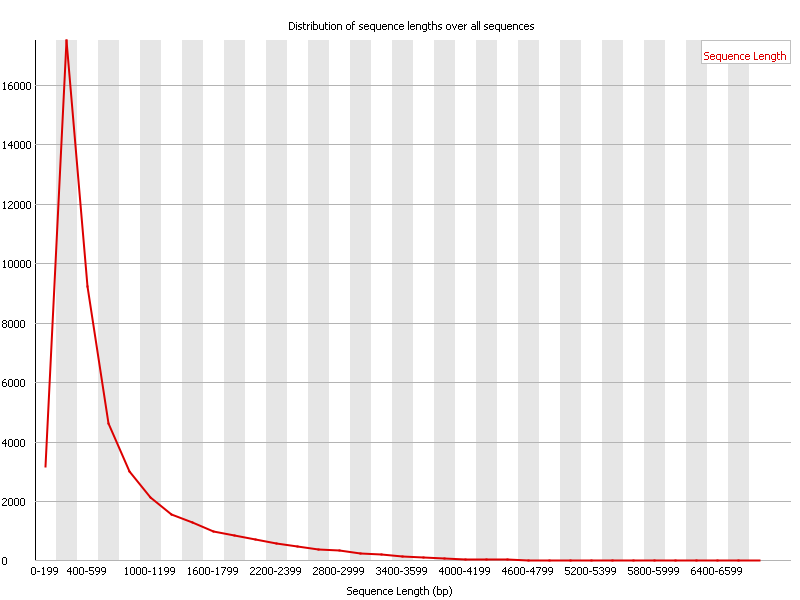

HTS platforms generate reads of uniform length, while others produce reads of varying lengths. Even in libraries with initially uniform read lengths, pre-processing steps such as quality trimming can shorten reads by removing low-quality bases from the ends, resulting in a dataset with a range of read lengths.

This module generates a graph that shows a single peak for uniform-length reads. For libraries with variable read lengths, the graph displays the relative abundance of reads at each fragment size.

Flags:

- **Warning**: if all sequences are not the same length.
- **Failure**: if any of the sequences have zero length.

**Sequence duplication levels**: plot showing the relative number of reads (y-axis) with different degrees of duplication (y-axis), where sequences with more than 10 duplicates are grouped into bins:

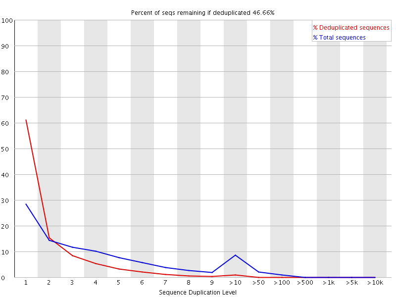

The x-axis represents the number of times a specific sequence appears in the file, with bin “1” representing unique sequences (i.e., seen only once) and bins “>10” to “>10k” representing sequences that are highly repetitive. On the y-axis, blue curve (“Total sequences”) quantifies the percentage of all reads in the file that belong to a specific duplication bin. For instance, if the blue line is at 10% for the “3” bin, it means that 10% of every single read in the FASTQ file belongs to a sequence that appears exactly 3 times. The red curve (“Deduplicated sequences”) quantifies instead the proportion of the deduplicated (i.e., unique, after leeping only one copy of every sequence) set that originated from each duplication level. In the plot above, the blue line is higher than the red line on the right side, indicating that a large fraction of the raw data consists of duplicates rather than unique information.

The starting point of the red curve, for bin “1”, represent the percentage of reads that have a unique sequence, i.e., present only once. In a well-diverse library, most sequences fall into the far-left bins in both red and blue lines. General enrichment or over-sequencing tends to flatten the lines, reducing the low-end proportion and increasing other bins. Specific enrichment of subsets or low-complexity contaminants produces spikes toward the right of the plot. These high-duplication peaks usually appear in the blue trace but often disappear in the red trace, indicating that they represent a small fraction of the deduplicated set. If peaks persist in the red trace, this suggests a large number of different highly duplicated sequences, possibly indicating contamination or severe technical duplication.

The module also calculates the expected overall loss of sequences if the library were fully deduplicated. This summary figure, displayed at the top of the plot, provides a reasonable estimate of potential sequence loss.

Flags:

- **Warning**: if non-unique sequences make up more than 20% of the total.
- **Failure**: if non-unique sequences make up more than 50% of the total.

In a diverse library, most sequences appear only once. Low duplication can reflect high coverage, while high duplication usually indicates enrichment bias. Duplicates can be technical (PCR artifacts) or biological (natural repeated sampling), but they cannot be distinguished at the sequence level. Warnings about duplication indicate reduced library diversity and potential over-sequencing, though some library types-such as RNA-seq naturally show high duplication due to highly expressed transcripts being repeatedly sampled.

**Overrepresented sequences**: lists of all of the sequence which make up more than 0.1% of the total. A normal HTS library contains a diverse set of sequences, with no individual sequence making up a tiny fraction of the whole. Finding that a single sequence is very over-represented in the set either means that it is highly biologically significant, or indicates that the library is contaminated or not as diverse as expected.

For each overrepresented sequence, FastQC searches a database of common contaminants and reports the best match. Matches must be at least 20 bp long with no more than one mismatch. Since many adapter sequences are highly similar, some hits may not be exact but still indicate a closely related sequence.

Flags:

- **Warning**: if any sequence is found to represent more than 0.1% of the total.
- **Failure**: if any sequence is found to represent more than 1% of the total.

**Adapter content**: cumulative percentage of the library containing each adapter sequence (y-axis, different colors) at each read position (x-axis). A results trace is always generated for all sequences listed in the FastQC adapter annotation file to assess adapter contamination in the library.

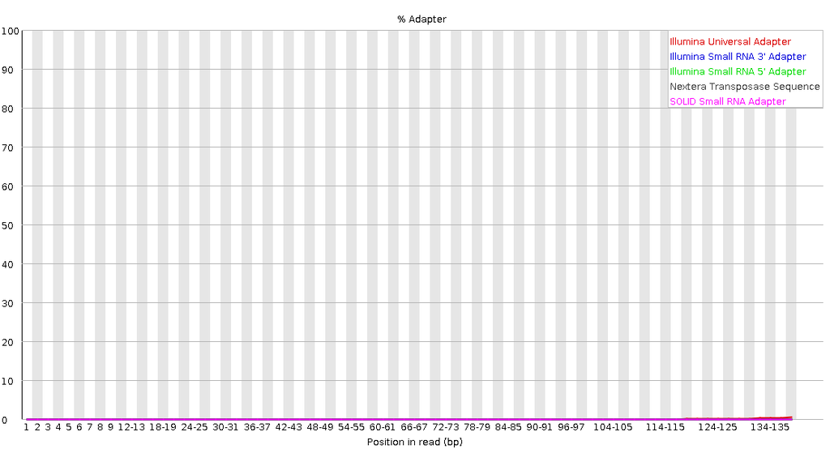

Flags:

- **Warning**: if any sequence is present in more than 5% of all reads.
- **Failure**: if any sequence is present in more than 10% of all reads.

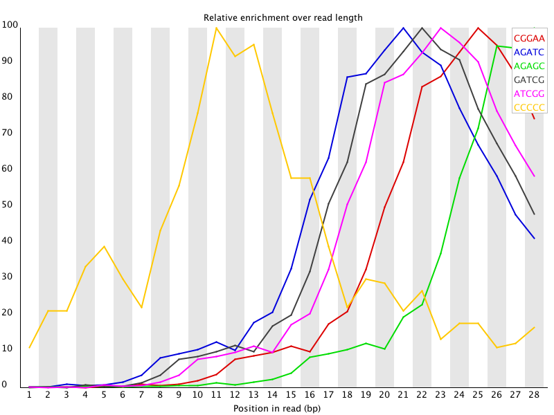

Flags:

- **Warning**: Tif any k-mer is imbalanced with a binomial p-value <0.01.
- **Failure**: if any k-mer is imbalanced with a binomial p-value < 10^-5.

Individually overrepresented sequences can drive significant K-mer enrichment, even when those sequences fall below the detection threshold of the “Overrepresented Sequences” module. This typically manifests as sharp, position-specific spikes rather than broad or gradual enrichment across the read. Furthermore, libraries generated via random priming often exhibit K-mer bias at the start of reads, a result of the non-random binding or incomplete sampling of the hexamer primers during library preparation.

# Exercises

## Exercise 1

At this link, you can see an example FastQC report for an Illumina dataset: [Illumina - exercise 1](https://computationalbiomedicinegroup.github.io/fqcabc2026/g_sequence_short_fastqc.html).

❓ **Question:** What is the total number of sequences in this dataset? Were any sequences identified as low-quality?

**Click to see the answer**

**Answer:**

The report shows 250,000 sequences (or reads), and none of them is flagged as “poor quality”.

❓ **Question:** What is the length of the reads?

**Click to see the answer**

**Answer:**

All reads have the same length: 40 bp.

❓ **Question:** What is the quality of the reads according to the “Per base sequence quality” module?

**Click to see the answer**

**Answer:**

This plot shows consistently high quality scores across the read sequence. A slight decrease is observed toward the end of the read (from around position 33), but overall quality remains high (>28, green region). Accordingly, this module is flagged as “pass,” confirming the high quality of the library.

❓ **Question:** Are there any issues in terms of sequence content, GC content, duplication levels, overrepresentation, or adapter content? Overall, how would you assess the quality of this dataset?

**Click to see the answer**

**Answer:**

There are no issues related to sequence content, GC content, duplication levels, overrepresented sequences, or adapter contamination. All corresponding modules report a “pass” flag, and the associated statistics and plots show no detectable bias. Overall, the dataset is of high quality and does not require any additional preprocessing, such as adapter removal or read trimming.

## Exercise 2

At this link, you can see a FastQC report for another an Illumina dataset: [Illumina - exercise 2](https://computationalbiomedicinegroup.github.io/fqcabc2026/b_sequence_fastqc.html).

❓ **Question:** What is the total number of sequences in this dataset? Were any sequences identified as low-quality?

**Click to see the answer**

**Answer:**

The report shows 395,288 sequences (or reads), and none of them is flagged as “poor quality”.

❓ **Question:** What is the length of the reads?

**Click to see the answer**

**Answer:**

All reads have the same length: 40 bp.

❓ **Question:** What is the quality of the reads according to the “per base sequence quality” module?

**Click to see the answer**

❓ **Question:** How do you interpret the results reported by the “per tile sequence quality” module?

**Click to see the answer**

**Answer:**

This plot displays the deviation from the average quality score across the flowcell, where the blue background represents high-quality data. The presence of red and orange streaks indicates specific physical locations on the flowcell (tiles) where sequencing quality dropped significantly, likely due to technical artifacts like bubbles, debris, or a temporary loss of focus during the run.

❓ **Question:** How do you interpret the results reported by the “per base sequence content” module?

**Click to see the answer**

**Answer:**

This plot shows the proportion of each nucleotide (A,T,C, and G) across all reads, which ideally should remain parallel and constant throughout the run. This plot has a warning because of the fluctuations at the beginning of the reads.

❓ **Question:** How do you interpret the results reported by the “per sequence GC content” module?

**Click to see the answer**

**Answer:**

This plot compares the actual GC distribution of the library (red line) against a modeled theoretical normal distribution (blue line). A warning is triggered because the data shows a jagged peak and a slight shift from the theoretical curve, which could indicate the presence of specific overrepresented sequences or minor contamination from a source with a different GC profile.

❓ **Question:** How do you interpret the results reported by the “sequence duplication levels” module?

**Click to see the answer**

**Answer:**

This plot illustrates what percentage of the library is made up of non-unique sequences and is characterized by a sharp peak at the >1k bin, which triggers a warning in this module. This high level of duplication often suggests a low-complexity library where technical over-amplification during PCR has created many identical copies of the same original fragments.

❓ **Question:** How do you interpret the results reported by the “overrepresented sequences” module?

**Click to see the answer**

**Answer:**

This table lists several sequences that appear in the dataset at a significantly higher frequency than expected. Only one of those sequences is identified as an Illumina PCR primer, whereas the others are marked as “No Hit”, which means that they could not be assigned to known sequences present in the FastQC database. Still, their high abundance suggests they may be technical artifacts, adapters, or highly expressed biological transcripts that dominate the sequencing pool, which would require a tailored preprocessing.

❓ **Question:** What are your overall considerations on this QC report and how could improve the quality of this dataset?

**Click to see the answer**

**Answer:**

Multiple modules are flagged as *fail* (per base sequence quality, per tile sequence quality) or *warning* (per base sequence content, per sequence GC content, sequence duplication levels, overrepresented sequences), indicating a suboptimal quality of this dataset. To improve the quality before proceding with downstream analysis, the following steps would be recommended: 1) adapter/primer sequence trimming; 2) filtering of low-quality reads; 3) identification and removal of overrepresented sequences, if possible; 4) removal of PCR duplicates; 5) QC analysis with FastQC on the preprocessed data. If you were preparing this dataset for downstream analysis, what sequence of steps would you recommend to improve its quality?

## Exercise X

Let’s consider a third FastQC report, generated for a mouse sample subjected to RNA-seq with the Illumina platform: [Illumina - exercise X](https://computationalbiomedicinegroup.github.io/fqcabc2026/fastqc_report.html).

Explore the results for all the modules and, based on the methodologies and insights learned from the previous exercises and on the guiding questions below, summarize the characteristics of this dataset and suggest a strategy for further processing and QC improvement.

❓ **Question:** What are the main characteristics of this datset in terms of number of reads, read length, etc.?

❓ **Question:** Which modules are flagged as “pass” and why?

❓ **Question:** Which modules are flagged as “warning” of “fail”, and why are they problematic?

❓ **Question:** What are your overall considerations on this QC report and how could improve the quality of this dataset?